# Manipulation de Fichier JSON avec R

### Confirmons le type de la variable results

```r
class(fichier_drug1_results)
```

```
## [1] "data.frame"
```

### Aperçu de la variable Results

```r
glimpse(fichier_drug1_results)
```

```
## Rows: 20,000
## Columns: 141
## $ active_ingredient                                                <list> [...
## $ storage_and_handling                                             <list> [...
## $ warnings                                                         <list> [...
## $ inactive_ingredient                                              <list> [...
## $ do_not_use                                                       <list> [...
## $ openfda                                                          <df[,21]> ...
## $ keep_out_of_reach_of_children                                    <list> [...
## $ spl_product_data_elements                                        <list> [...
## $ package_label_principal_display_panel                            <list> [...
## $ set_id                                                           <chr> "a...
## $ dosage_and_administration                                        <list> [...
## $ version                                                          <chr> "1...
## $ stop_use                                                         <list> [...
```

[output cut: 128 more lines]

*On peut se rendre compte que notre variable possède, 20.000 observations et 141 colonnes.* *On peut également se rendre compte que ce que nous cherchons c’est un dataframe et nous le voyons dans la variable Openfda inclu dans results*

### Contenu de la variable Openfda contenu dans results

```r
glimpse(fichier_drug1_results$openfda)
```

```
## Rows: 20,000
## Columns: 21
## $ manufacturer_name             <list> ["Tonic Bath & Products Shenzhen Ltd...
## $ unii                          <list> ["3K9958V90M", <"G63QQF2NOX", "95OOS...
## $ product_type                  <list> ["HUMAN OTC DRUG", "HUMAN OTC DRUG",...
## $ rxcui                         <list> ["2050977", NULL, NULL, NULL, "90528...
## $ spl_set_id                    <list> ["a517190f-2a21-3016-e053-2a95a90abd...
## $ route                         <list> ["TOPICAL", "TOPICAL", "TOPICAL", NU...
## $ generic_name                  <list> ["ETHYL ALCOHOL", "AVOBENZONE, HOMOS...
## $ brand_name                    <list> ["Hand Sanitizer", "KROGER SPORT SPF...
## $ product_ndc                   <list> ["43333-484", "30142-808", "76841-48...
## $ substance_name                <list> ["ALCOHOL", <"OCTISALATE", "OXYBENZO...
## $ spl_id                        <list> ["a51710ae-6bcc-a672-e053-2995a90aae...
## $ application_number            <list> ["part333A", "part352", "part333A", ...
## $ is_original_packager          <list> [TRUE, TRUE, TRUE, NULL, NULL, TRUE,...
## $ package_ndc                   <list> ["43333-484-08", "30142-808-37", "76...
## $ upc                           <list> [NULL, "0041260383328", NULL, NULL, ...
## $ original_packager_product_ndc <list> [NULL, NULL, NULL, NULL, "70954-211"...
## $ nui                           <list> [NULL, NULL, NULL, NULL, NULL, NULL,...
## $ pharm_class_epc               <list> [NULL, NULL, NULL, NULL, NULL, NULL,...
## $ pharm_class_pe                <list> [NULL, NULL, NULL, NULL, NULL, NULL,...
## $ pharm_class_cs                <list> [NULL, NULL, NULL, NULL, NULL, NULL,...
## $ pharm_class_moa               <list> [NULL, NULL, NULL, NULL, NULL, NULL,...
```

*Nous pouvons observer 21 colonnes et 20.000 observations, ce qui est déjà mieux.*

# Fusionnons tous les fichiers pour nos analyses.

**Nous allons inclure 2 autres variables, “effective_time” et “boxed_warning”**

```r
# Affectation des 2 colonnes dans la variable "effective_time" et "boxed_warning"
result_1 <- fromJSON(liste_fichier_json[1])$results %>% select(effective_time,boxed_warning)
result_2 <- fromJSON(liste_fichier_json[2])$results %>% select(effective_time,boxed_warning)
result_3 <- fromJSON(liste_fichier_json[3])$results %>% select(effective_time,boxed_warning)
result_4 <- fromJSON(liste_fichier_json[4])$results %>% select(effective_time,boxed_warning)
result_5 <- fromJSON(liste_fichier_json[5])$results %>% select(effective_time,boxed_warning)

# Concatenons tous ces résultats
spl <- rbind(result_1,result_2,result_3,result_4,result_5)
```

### Dimension de la variable spl?

```r
cat("Notre variable spl contient",nrow(spl),"lignes et",ncol(spl),"colonnes")
```

```
## Notre variable spl contient 100000 lignes et 2 colonnes
```

### Structure de ces 2 colonnes que nous venons de concatener

```r
glimpse(spl)
```

```
## Rows: 100,000
## Columns: 2
## $ effective_time <chr> "20200507", "20200508", "20200510", "20181108", "201...
## $ boxed_warning  <list> [NULL, NULL, NULL, NULL, NULL, NULL, NULL, NULL, NU...
```

*Un bémole ici, boxed_warning est une liste et effective_time un string*

# Comprendre la donnée “effective_time”

### Nombre max de caractère

```r
cat('Nombre maximal de caractère dans la variable effective_time :',max(nchar(spl$effective_time)))
```

```
## Nombre maximal de caractère dans la variable effective_time : 10
```

### Nombre min de caractère

```r
cat('Nombre minimal de caractère dans la variable effective_time :',min(nchar(spl$effective_time)))
```

```
## Nombre minimal de caractère dans la variable effective_time : 8
```

### Nombre de ligne par caractéristique de la variable “effective_time”

```r
spl %>% group_by(nchar(effective_time)) %>% summarise(nombre = n())
```

```
## # A tibble: 3 x 2
##   `nchar(effective_time)` nombre
##                     <int>  <int>
## 1                       8  99998
## 2                       9      1
## 3                      10      1
```

### Regardons la valeur de “effective_time” qui possède 10 caractères.

```r
spl %>% filter(nchar(effective_time) == 10) %>% select(effective_time)
```

```
##   effective_time
## 1     2009103009
```

### Regardons la valeur de “effective_time” qui possède 9 caractères.

```r
spl %>% filter(nchar(effective_time) == 9) %>% select(effective_time)
```

```
##   effective_time
## 1      201108178
```

```r
# Affichons juste les 6 premières lignes
head(spl %>% filter(nchar(effective_time) == 8)) %>%  select(effective_time)
```

```
##   effective_time
## 1       20200507
## 2       20200508
## 3       20200510
## 4       20181108
## 5       20191110
## 6       20150925
```

### Extraction des 8 premiers caractères de “effective_time” ayant 9 et 10 caractères

```r
spl <- spl %>% mutate(effective_time = stri_sub(effective_time,1,8))
```

*Vérifions si toutes nos lignes ont désormais 8 caractères (nous devons avoir maintenant 100.000)*

```r
spl %>% group_by(nchar(effective_time)) %>% summarise(nombre = n())
```

```
## # A tibble: 1 x 2
##   `nchar(effective_time)` nombre
##                     <int>  <int>
## 1                       8 100000
```

*C’est parfait, toutes nos lignes de “effective_time” ont désormais le nombre de caractères requis*

```r
# Convertissons en format date
spl <- spl %>% mutate(effective_time = lubridate::ymd(effective_time))

# Vérifions les si les changements ont eu lieu
glimpse(spl)
```

```
## Rows: 100,000
## Columns: 2
## $ effective_time <date> 2020-05-07, 2020-05-08, 2020-05-10, 2018-11-08, 201...
## $ boxed_warning  <list> [NULL, NULL, NULL, NULL, NULL, NULL, NULL, NULL, NU...
```

### Nombre de soumissions par jour

```r
# Requête
soumission_par_jour <- spl %>% group_by(effective_time) %>% summarise(nombre_de_valeur = n())
```

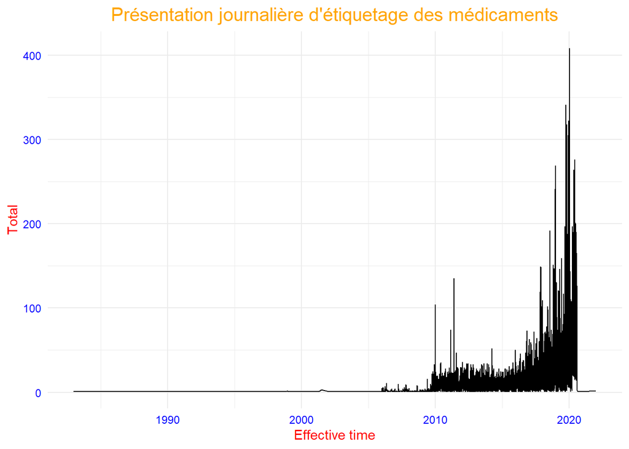

```r
# Graphe
graphe_1 <- soumission_par_jour %>% ggplot(aes(effective_time, nombre_de_valeur)) +
                                    geom_line() +
                                    ggtitle("Présentation journalière d'étiquetage des médicaments") +
                                    xlab("Effective time") +
                                    ylab("Total") +
                                    theme_minimal() +
                                    theme(axis.title.x = element_text(color = "red"),
                                          axis.title.y = element_text(color = "red"),
                                          axis.text = element_text(color = "blue"),
                                          plot.title = element_text(size = 15, hjust = 0.5, color = "Orange"))
graphe_1
```

*On peut se rendre compte qu’il y’a peu de données avant 2009*

### Enlevons les données avant 2009

```r
# Requête
req_1 <- spl %>% group_by(effective_time) %>% filter(effective_time > "2008-12-31") %>% summarise(nombre_de_valeur = n())
```

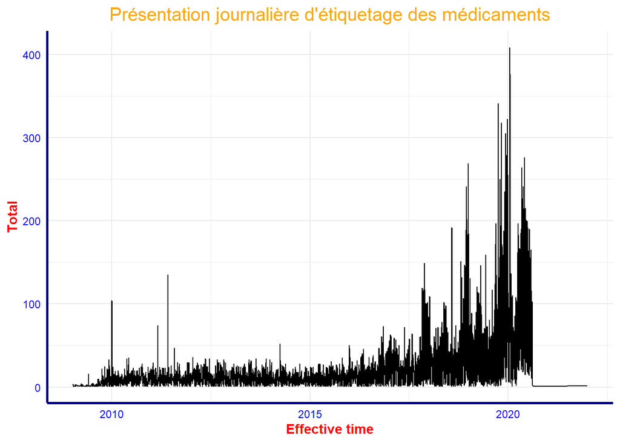

```r
# Graphe
graphe_2 <- req_1 %>% ggplot(aes(effective_time, nombre_de_valeur)) +
                      geom_line() +
                      ggtitle("Présentation journalière d'étiquetage des médicaments") +
                      xlab("Effective time") +
                      ylab("Total") +
                      theme_minimal() +
                      theme(axis.title.x = element_text(color = "red", face = "bold"),
                            axis.title.y = element_text(color = "red", face = "bold"),
                            axis.text = element_text(color = "blue"),
                            plot.title = element_text(size = 15, hjust = 0.5, color = "Orange"),
                            legend.background = element_rect(fill = "lightblue",
                            size=0.5, linetype="solid", colour = "red"),
                            legend.text = element_text(colour = "blue", face = "bold"),
                            legend.title = element_text(colour = "red", size = 10,face = "bold", hjust = 0.5),
                            axis.line = element_line(colour = "darkblue", size = 1, linetype = "solid"))
graphe_2
```

*ce graphe peut nous informer sur la tendance mais il est toujours illisible et ne nous aide pas énormément. Essayons de trouver le nombre de rapport par année*

### présentation annuelle d’étiquetage des médicaments

```r
# Requête
req_2 <- spl %>% mutate(annee = lubridate::year(effective_time)) %>% group_by(annee) %>% filter(annee > "2008") %>% summarise(nombre_de_valeur = n())
```

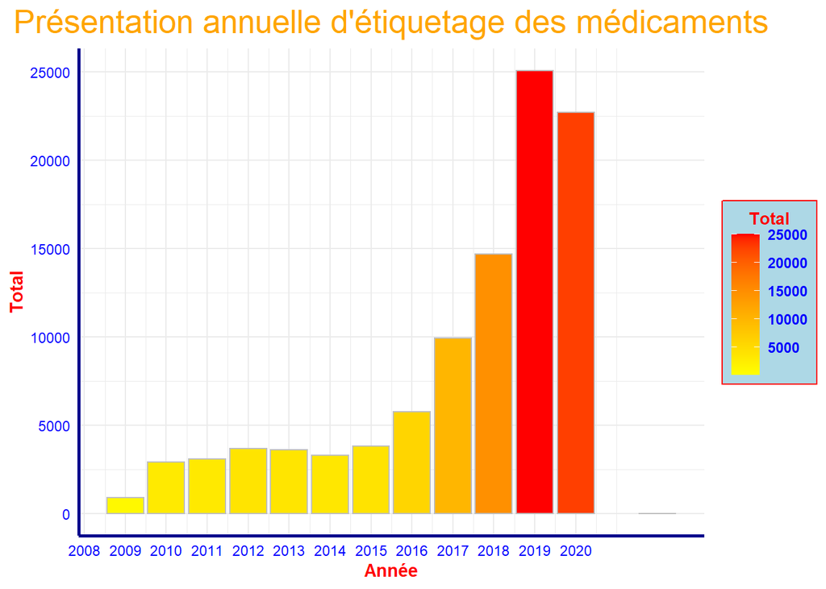

```r
# Graphe
graphe_3 <- req_2 %>% ggplot(aes(annee, nombre_de_valeur, fill = nombre_de_valeur)) +
                      geom_bar(stat = "identity", color = "grey") +
                      ggtitle("Présentation annuelle d'étiquetage des médicaments") +
                      xlab("Année") +
                      ylab("Total") +
                      theme_minimal() +
                      labs(fill = "Total") +
                      scale_fill_gradient(low = "yellow", high = "red") +
                      scale_x_continuous(breaks=seq(2008, 2020, by = 1))+
                      theme(axis.title.x = element_text(color = "red", face = "bold"),
                            axis.title.y = element_text(color = "red", face = "bold"),
                            axis.text = element_text(color = "blue"),
                            plot.title = element_text(size = 20, hjust = 0.5, color = "Orange"),
                            legend.background = element_rect(fill = "lightblue",
                            size=0.5, linetype="solid", colour = "red"),
                            legend.text = element_text(colour = "blue", face = "bold"),
                            legend.title = element_text(colour = "red", size = 10,face = "bold", hjust = 0.5),
                            axis.line = element_line(colour = "darkblue", size = 1, linetype = "solid"))
graphe_3
```

### L’avertissement le plus fort exigé par la FDA:

*Qui indique que le médicament comporte un risque important d’effets indésirables graves, voire mortels.*

```r
# Ici j'ai dû tester plein d'intervalle par contre séquencer par pas de 100
for(i in 16:20){
  print(select(spl,boxed_warning)[i,])
}
```

```
## [[1]]
## NULL
##
## [[1]]
## NULL
##
## [[1]]
## [1] "WARNING: ADDICTION, ABUSE, AND MISUSE: RISK EVALUATION AND MITIGATION STRATEGY (REMS); LIFE-THREATENING RESPIRATORY DEPRESSION; ACCIDENTAL INGESTION; NEONATAL OPIOID; WITHDRAWAL SYNDROME; CYTOCHROME P450 3A4 INTERACTION; HEPATOTOXICITY AND RISKS FROM CONCOMITANT USE WITH BENZODIAZEPINES OR O…
##
## [[1]]
## NULL
##
## [[1]]
## NULL
```

*Nous pouvons voir quele warning correspond à notre warning que nous recherchons*

### Changeons les “NULL” en “NA”

```r
# changeons les "NULL" en "NA"
spl$boxed_warning[spl$boxed_warning == "NULL"] = NA

# Vérifions si les changements ont été opéré
head(spl$boxed_warning)
```

```
## [[1]]
## [1] NA
##
## [[2]]
## [1] NA
##
## [[3]]
## [1] NA
##
## [[4]]
## [1] NA
##
## [[5]]
## [1] NA
##
## [[6]]
## [1] NA
```

### Présentation annuelle d’étiquetage des médicaments avec avertissement encadré

```r
# Requête
req_3 <- spl %>% mutate(annee = lubridate::year(effective_time)) %>% group_by(annee) %>% filter(annee > "2008") %>% summarise(nombre_precaution = sum(!is.na(boxed_warning)))
```

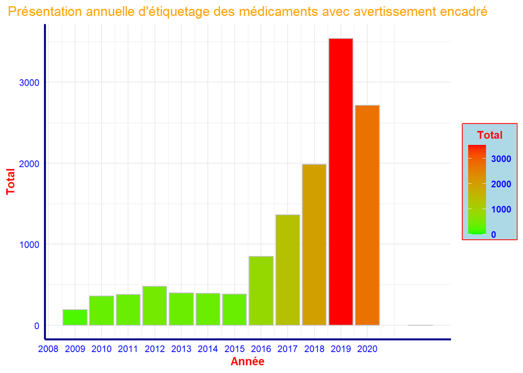

```r
# Graphe
graphe_4 <- req_3 %>% ggplot(aes(annee, nombre_precaution, fill = nombre_precaution)) +
                      geom_bar(stat = "identity", color = "grey") +
                      ggtitle("Présentation annuelle d'étiquetage des médicaments avec avertissement encadré") +
                      xlab("Année") +
                      ylab("Total") +
                      theme_minimal() +
                      labs(fill = "Total") +
                      scale_fill_gradient(low = "green", high = "red") +
                      scale_x_continuous(breaks=seq(2008, 2020, by = 1))+
                      theme(axis.title.x = element_text(color = "red", face = "bold"),
                            axis.title.y = element_text(color = "red", face = "bold"),
                            axis.text = element_text(color = "blue"),
                            plot.title = element_text(size = 13, hjust = 0.5, color = "Orange"),
                            legend.background = element_rect(fill = "lightblue",
                            size=0.5, linetype="solid", colour = "red"),
                            legend.text = element_text(colour = "blue", face = "bold"),
                            legend.title = element_text(colour = "red", size = 10,face = "bold", hjust = 0.5),
                            axis.line = element_line(colour = "darkblue", size = 1, linetype = "solid"))
graphe_4
```

### Aperçu des uniques précautions

```r
head(unique(spl$boxed_warning))
```

```
## [[1]]
## [1] NA
##
## [[2]]
## [1] "WARNING: ADDICTION, ABUSE, AND MISUSE: RISK EVALUATION AND MITIGATION STRATEGY (REMS); LIFE-THREATENING RESPIRATORY DEPRESSION; ACCIDENTAL INGESTION; NEONATAL OPIOID; WITHDRAWAL SYNDROME; CYTOCHROME P450 3A4 INTERACTION; HEPATOTOXICITY AND RISKS FROM CONCOMITANT USE WITH BENZODIAZEPINES OR O…
##
## [[3]]
## [1] "BOXED WARNING Cessation of Therapy with TENORMINPatients with coronary artery disease, who are being treated with TENORMIN, should be advised against abrupt discontinuation of therapy. Severe exacerbation of angina and the occurrence of myocardial infarction and ventricular arrhythmias have …
##
## [[4]]
## [1] "*Based on a review of this drug (isometheptene mucate) by the National Academy of Sciences - National Research Council and/or other information, FDA has classified the other indication as \"possibly\" effective in the treatment of migraine headache. Final classification of the less-than-effe…
##
## [[5]]
## [1] "BOXED WARNING Hepatotoxicity: Acetaminophen has been associated with cases of acute liver failure, at times resulting in liver transplant and death. Most of the cases of liver injury are associated with the use of acetaminophen at doses that exceed 4000 milligrams per day, and often involve …
##
## [[6]]
## [1] "SUICIDALITY AND ANTIDEPRESSANT DRUGS Antidepressants increased the risk compared to placebo of suicidal thinking and behavior (suicidality) in children, adolescents, and young adults in short-term studies of major depressive disorder (MDD) and other psychiatric disorders. Anyone considering …
```

### Changeons la boxed_warning qui est une liste en caractère (“unlist”)

```r
# Transformons les [NA,NA] en ["NA","NA"]
for(i in 1:nrow(spl)){
  spl$boxed_warning[i] = paste0(unlist(spl$boxed_warning[i]),collapse = ",")
}

# Délistons la colonne entière, nous partirons de ["NA","NA"] à "NA","NA"
spl$boxed_warning = unlist(spl$boxed_warning)
```

### Voyons si les changements ont été opéré

```r
glimpse(spl)
```

```
## Rows: 100,000
## Columns: 2
## $ effective_time <date> 2020-05-07, 2020-05-08, 2020-05-10, 2018-11-08, 201...
## $ boxed_warning  <chr> "NA", "NA", "NA", "NA", "NA", "NA", "NA", "NA", "NA"...
```

# Ajoutons des variables additionnelles

```r
# Récupérons les dataframes nommés OpenFDA du Json et Sélectionnons les colonnes qui nous interessent
openfda_1 <- fromJSON(liste_fichier_json[1])$results$openfda %>% select(manufacturer_name, product_type, route, generic_name, brand_name, substance_name)

openfda_2 <- fromJSON(liste_fichier_json[2])$results$openfda %>% select(manufacturer_name, product_type, route, generic_name, brand_name, substance_name)

openfda_3 <- fromJSON(liste_fichier_json[3])$results$openfda %>% select(manufacturer_name, product_type, route, generic_name, brand_name, substance_name)

openfda_4 <- fromJSON(liste_fichier_json[4])$results$openfda %>% select(manufacturer_name, product_type, route, generic_name, brand_name, substance_name)

openfda_5 <- fromJSON(liste_fichier_json[5])$results$openfda %>% select(manufacturer_name, product_type, route, generic_name, brand_name, substance_name)

# Concatenons les openfda par ligne
spl_openfda <- rbind(openfda_1,openfda_2,openfda_3,openfda_4,openfda_5)
```

### Aperçu de notre variable “openfda_spl”

```r
glimpse(spl_openfda)
```

```
## Rows: 100,000
## Columns: 6
## $ manufacturer_name <list> ["Tonic Bath & Products Shenzhen Ltd", "THE KROG...
## $ product_type      <list> ["HUMAN OTC DRUG", "HUMAN OTC DRUG", "HUMAN OTC ...
## $ route             <list> ["TOPICAL", "TOPICAL", "TOPICAL", NULL, "ORAL", ...
## $ generic_name      <list> ["ETHYL ALCOHOL", "AVOBENZONE, HOMOSALATE, OCTIS...
## $ brand_name        <list> ["Hand Sanitizer", "KROGER SPORT SPF 15 SUNSCREE...
## $ substance_name    <list> ["ALCOHOL", <"OCTISALATE", "OXYBENZONE", "HOMOSA...
```

*On peut observer que nous avons dans notre dataframe spl_openfda a 100.000 lignes et 6 colonnes*

# Colonne “product_type”

### Vérifions si nous avons des “NULL” dans la colonne “product_type”

```r
"NULL" %in% (spl_openfda$product_type)
```

```
## [1] TRUE
```

```r
# On peut aussi passer par l'unicité de la colonne pour trouver les 3 valeurs uniques: "HUMAN OTC DRUG", "HUMAN PRESCRIPTION DRUG" et "NULL"
# unique(spl_openfda$product_type)
```

### Changeons les “NULL” en “NA”

```r
spl_openfda$product_type[spl_openfda$product_type == "NULL"] = NA

# Vérifions l'unicité pour voir si les changemants ont bien eu lieu
unique(spl_openfda$product_type)
```

```
## [[1]]
## [1] "HUMAN OTC DRUG"
##
## [[2]]
## [1] NA
##
## [[3]]
## [1] "HUMAN PRESCRIPTION DRUG"
```

*Nous pouvons voir qu’il n’existe plus de “NULL” dans la colonne “product_type”*

### Délistons la colonne “product_type”

```r
for(i in 1:nrow(spl_openfda)){
      spl_openfda$product_type[i]=paste0(unlist(spl_openfda$product_type[i]),collapse=",")
}

spl_openfda <- spl_openfda %>% mutate(product_type = unlist(product_type))
```

# Colonne “route”

### Vérifions si nous avons des “NULL” dans la colonne “route”

```r
"NULL" %in% (spl_openfda$route)
```

```
## [1] TRUE
```

### Changeons les “NULL” en “NA”

```r
spl_openfda$route[spl_openfda$route == "NULL"] = NA

# Vérifions l'unicité pour voir si les changemants ont bien eu lieu (aperçu des 20 premières lignes)
head(unique(spl_openfda$route), 20)
```

```
## [[1]]
## [1] "TOPICAL"
##
## [[2]]
## [1] NA
##
## [[3]]
## [1] "ORAL"
##
## [[4]]
## [1] "BUCCAL"
##
## [[5]]
## [1] "EXTRACORPOREAL"
##
## [[6]]
## [1] "DENTAL"
##
## [[7]]
## [1] "OPHTHALMIC"
##
## [[8]]
## [1] "RESPIRATORY (INHALATION)"
##
## [[9]]
## [1] "AURICULAR (OTIC)"
##
## [[10]]
## [1] "CUTANEOUS"
##
## [[11]]
## [1] "VAGINAL"
##
## [[12]]
## [1] "TOPICAL" "DENTAL"
##
## [[13]]
## [1] "INTRAMUSCULAR" "PARENTERAL"    "INTRAVENOUS"   "SUBCUTANEOUS"
##
## [[14]]
## [1] "INTRAVENOUS"
##
## [[15]]
## [1] "INTRAMUSCULAR" "INTRAVENOUS"
##
## [[16]]
## [1] "PERIODONTAL" "DENTAL"      "ORAL"
##
## [[17]]
## [1] "PARENTERAL"
##
## [[18]]
## [1] "DENTAL" "ORAL"
##
## [[19]]
## [1] "SUBLINGUAL"
##
## [[20]]
## [1] "TRANSDERMAL"
```

```r
# Y'a t-il encore des "NULL"?
"NULL" %in% (spl_openfda$route)
```

```
## [1] FALSE
```

*Nous pouvons voir qu’il n’existe plus de “NULL” dans la colonne “route”*

```r
for(i in 1:nrow(spl_openfda)){
      spl_openfda$route[i]=paste0(unlist(spl_openfda$route[i]),collapse=",")
}

spl_openfda <- spl_openfda %>% mutate(route=unlist(route))
```

### Vérifions l’unicité pour voir si les changemants ont bien eu lieu (aperçu des 20 premières lignes)

```r
head(unique(spl_openfda$route),20)
```

```
##  [1] "TOPICAL"
##  [2] "NA"
##  [3] "ORAL"
##  [4] "BUCCAL"
##  [5] "EXTRACORPOREAL"
##  [6] "DENTAL"
##  [7] "OPHTHALMIC"
##  [8] "RESPIRATORY (INHALATION)"
##  [9] "AURICULAR (OTIC)"
## [10] "CUTANEOUS"
## [11] "VAGINAL"
## [12] "TOPICAL,DENTAL"
## [13] "INTRAMUSCULAR,PARENTERAL,INTRAVENOUS,SUBCUTANEOUS"
## [14] "INTRAVENOUS"
## [15] "INTRAMUSCULAR,INTRAVENOUS"
## [16] "PERIODONTAL,DENTAL,ORAL"
## [17] "PARENTERAL"
## [18] "DENTAL,ORAL"
## [19] "SUBLINGUAL"
## [20] "TRANSDERMAL"
```

# Colonne “manufacturer_name”

### Vérifions si nous avons des “NULL” dans la colonne “manufacturer_name”

```r
"NULL" %in% (spl_openfda$manufacturer_name)
```

```
## [1] TRUE
```

### Changeons les “NULL” en “NA”

```r
spl_openfda$manufacturer_name[spl_openfda$manufacturer_name == "NULL"] = NA

# Vérifions l'unicité pour voir si les changemants ont bien eu lieu (aperçu des 5 premières lignes)
head(unique(spl_openfda$manufacturer_name), 5)
```

```
## [[1]]
## [1] "Tonic Bath & Products Shenzhen Ltd"
##
## [[2]]
## [1] "THE KROGER COMPANY"
##
## [[3]]
## [1] "Earth Edition Inc."
##
## [[4]]
## [1] NA
##
## [[5]]
## [1] "REMEDYREPACK INC."
```

```r
# Y'a t-il encore des "NULL"?
"NULL" %in% (spl_openfda$manufacturer_name)
```

```
## [1] FALSE
```

*Nous pouvons voir qu’il n’existe plus de “NULL” dans la colonne “manufacturer_name”*

### Délistons la colonne “manufacturer_name”

```r
for(i in 1:nrow(spl_openfda)){
      spl_openfda$manufacturer_name[i]=paste0(unlist(spl_openfda$manufacturer_name[i]),collapse=",")
}

spl_openfda <- spl_openfda %>% mutate(manufacturer_name=unlist(manufacturer_name))
```

### Vérifions l’unicité pour voir si les changemants ont bien eu lieu (aperçu des 5 premières lignes)

```r
head(unique(spl_openfda$manufacturer_name),5)
```

```
## [1] "Tonic Bath & Products Shenzhen Ltd" "THE KROGER COMPANY"
## [3] "Earth Edition Inc."                 "NA"
## [5] "REMEDYREPACK INC."
```

# Colonne “generic_name”

### Vérifions si nous avons des “NULL” dans la colonne “generic_name”

```r
"NULL" %in% (spl_openfda$generic_name)
```

```
## [1] TRUE
```

### Changeons les “NULL” en “NA”

```r
spl_openfda$generic_name[spl_openfda$generic_name == "NULL"] = NA

# Vérifions l'unicité pour voir si les changemants ont bien eu lieu (aperçu des 5 premières lignes)
head(unique(spl_openfda$generic_name), 5)
```

```
## [[1]]
## [1] "ETHYL ALCOHOL"
##
## [[2]]
## [1] "AVOBENZONE, HOMOSALATE, OCTISALATE, OXYBENZONE"
##
## [[3]]
## [1] "ETHANOL"
##
## [[4]]
## [1] NA
##
## [[5]]
## [1] "TRIHEXYPHENIDYL HYDROCHLORIDE"
```

```r
# Y'a t-il encore des "NULL"?
"NULL" %in% (spl_openfda$generic_name)
```

```
## [1] FALSE
```

### Délistons la colonne “generic_name”

```r
for(i in 1:nrow(spl_openfda)){
      spl_openfda$generic_name[i]=paste0(unlist(spl_openfda$generic_name[i]),collapse=",")
}

spl_openfda <- spl_openfda %>% mutate(generic_name=unlist(generic_name))
```

```r
head(unique(spl_openfda$generic_name),5)
```

```
## [1] "ETHYL ALCOHOL"
## [2] "AVOBENZONE, HOMOSALATE, OCTISALATE, OXYBENZONE"
## [3] "ETHANOL"
## [4] "NA"
## [5] "TRIHEXYPHENIDYL HYDROCHLORIDE"
```

```r
glimpse(spl_openfda)
```

```
## Rows: 100,000
## Columns: 6
## $ manufacturer_name <chr> "Tonic Bath & Products Shenzhen Ltd", "THE KROGER...
## $ product_type      <chr> "HUMAN OTC DRUG", "HUMAN OTC DRUG", "HUMAN OTC DR...
## $ route             <chr> "TOPICAL", "TOPICAL", "TOPICAL", "NA", "ORAL", "T...
## $ generic_name      <chr> "ETHYL ALCOHOL", "AVOBENZONE, HOMOSALATE, OCTISAL...
## $ brand_name        <list> ["Hand Sanitizer", "KROGER SPORT SPF 15 SUNSCREE...
## $ substance_name    <list> ["ALCOHOL", <"OCTISALATE", "OXYBENZONE", "HOMOSA...
```

# Colonne “brand_name”

### Vérifions si nous avons des “NULL” dans la colonne “brand_name”

```r
"NULL" %in% (spl_openfda$brand_name)
```

```
## [1] TRUE
```

### Changeons les “NULL” en “NA”

```r
spl_openfda$brand_name[spl_openfda$brand_name == "NULL"] = NA

# Vérifions l'unicité pour voir si les changemants ont bien eu lieu (aperçu des 5 premières lignes)
head(unique(spl_openfda$brand_name), 5)
```

```
## [[1]]
## [1] "Hand Sanitizer"
##
## [[2]]
## [1] "KROGER SPORT SPF 15 SUNSCREEN"
##
## [[3]]
## [1] "EARTH EDITION HAND SANITIZER Gel"
##
## [[4]]
## [1] NA
##
## [[5]]
## [1] "TRIHEXYPHENIDYL HYDROCHLORIDE"
```

```r
# Y'a t-il encore des "NULL"?
"NULL" %in% (spl_openfda$brand_name)
```

```
## [1] FALSE
```

*Nous pouvons voir qu’il n’existe plus de “NULL” dans la colonne “brand_name”*

### Délistons la colonne “brand_name”

```r
for(i in 1:nrow(spl_openfda)){
      spl_openfda$brand_name[i]=paste0(unlist(spl_openfda$brand_name[i]),collapse=",")
}

spl_openfda <- spl_openfda %>% mutate(brand_name=unlist(brand_name))
```

```r
head(unique(spl_openfda$brand_name),5)
```

```
## [1] "Hand Sanitizer"                   "KROGER SPORT SPF 15 SUNSCREEN"
## [3] "EARTH EDITION HAND SANITIZER Gel" "NA"
## [5] "TRIHEXYPHENIDYL HYDROCHLORIDE"
```

```r
glimpse(spl_openfda)
```

```
## Rows: 100,000
## Columns: 6
## $ manufacturer_name <chr> "Tonic Bath & Products Shenzhen Ltd", "THE KROGER...
## $ product_type      <chr> "HUMAN OTC DRUG", "HUMAN OTC DRUG", "HUMAN OTC DR...
## $ route             <chr> "TOPICAL", "TOPICAL", "TOPICAL", "NA", "ORAL", "T...
## $ generic_name      <chr> "ETHYL ALCOHOL", "AVOBENZONE, HOMOSALATE, OCTISAL...
## $ brand_name        <chr> "Hand Sanitizer", "KROGER SPORT SPF 15 SUNSCREEN"...
## $ substance_name    <list> ["ALCOHOL", <"OCTISALATE", "OXYBENZONE", "HOMOSA...
```

# Colonne “substance_name”

### Vérifions si nous avons des “NULL” dans la colonne “substance_name”

```r
"NULL" %in% (spl_openfda$substance_name)
```

```
## [1] TRUE
```

### Changeons les “NULL” en “NA”

```r
spl_openfda$substance_name[spl_openfda$substance_name == "NULL"] = NA

# Vérifions l'unicité pour voir si les changemants ont bien eu lieu (aperçu des 5 premières lignes)
head(unique(spl_openfda$substance_name), 5)
```

```
## [[1]]
## [1] "ALCOHOL"
##
## [[2]]
## [1] "OCTISALATE" "OXYBENZONE" "HOMOSALATE" "AVOBENZONE"
##
## [[3]]
## [1] NA
##
## [[4]]
## [1] "TRIHEXYPHENIDYL HYDROCHLORIDE"
##
## [[5]]
## [1] "ASPIRIN"
```

```r
# Y'a t-il encore des "NULL"?
"NULL" %in% (spl_openfda$substance_name)
```

```
## [1] FALSE
```

*Nous pouvons voir qu’il n’existe plus de “NULL” dans la colonne “substance_name”*

### Délistons la colonne “substance_name”

```r
for(i in 1:nrow(spl_openfda)){
      spl_openfda$substance_name[i]=paste0(unlist(spl_openfda$substance_name[i]),collapse=",")
}

spl_openfda <- spl_openfda %>% mutate(substance_name=unlist(substance_name))
```

```r
head(unique(spl_openfda$substance_name),5)
```

```
## [1] "ALCOHOL"
## [2] "OCTISALATE,OXYBENZONE,HOMOSALATE,AVOBENZONE"
## [3] "NA"
## [4] "TRIHEXYPHENIDYL HYDROCHLORIDE"
## [5] "ASPIRIN"
```

```r
glimpse(spl_openfda)
```

```
## Rows: 100,000
## Columns: 6
## $ manufacturer_name <chr> "Tonic Bath & Products Shenzhen Ltd", "THE KROGER...
## $ product_type      <chr> "HUMAN OTC DRUG", "HUMAN OTC DRUG", "HUMAN OTC DR...
## $ route             <chr> "TOPICAL", "TOPICAL", "TOPICAL", "NA", "ORAL", "T...
## $ generic_name      <chr> "ETHYL ALCOHOL", "AVOBENZONE, HOMOSALATE, OCTISAL...
## $ brand_name        <chr> "Hand Sanitizer", "KROGER SPORT SPF 15 SUNSCREEN"...
## $ substance_name    <chr> "ALCOHOL", "OCTISALATE,OXYBENZONE,HOMOSALATE,AVOB...
```

# Requêtes:

### Le nombre de soumissions des plus fréquemment signalées par type de produit et par route.

```r
# Les 20 premières lignes par ordre décroissante
nb_submission <- spl_openfda %>% group_by(product_type, route) %>% summarise(total = n()) %>% arrange(desc(total)) %>% head(20)
nb_submission
```

```
## # A tibble: 20 x 3
## # Groups:   product_type [3]
##    product_type            route                     total
##    <chr>                   <chr>                     <int>
##  1 NA                      NA                        47107
##  2 HUMAN OTC DRUG          TOPICAL                   19209
##  3 HUMAN OTC DRUG          ORAL                      13370
##  4 HUMAN PRESCRIPTION DRUG ORAL                      11882
##  5 HUMAN PRESCRIPTION DRUG INTRAVENOUS                1385
##  6 HUMAN PRESCRIPTION DRUG TOPICAL                    1123
##  7 HUMAN PRESCRIPTION DRUG RESPIRATORY (INHALATION)    683
##  8 HUMAN OTC DRUG          NA                          616
##  9 HUMAN OTC DRUG          DENTAL                      516
## 10 HUMAN PRESCRIPTION DRUG INTRAMUSCULAR,INTRAVENOUS   423
## 11 HUMAN OTC DRUG          EXTRACORPOREAL              382
## 12 HUMAN PRESCRIPTION DRUG NA                          342
## 13 HUMAN OTC DRUG          OPHTHALMIC                  335
## 14 HUMAN PRESCRIPTION DRUG OPHTHALMIC                  312
## 15 HUMAN OTC DRUG          NASAL                       258
## 16 HUMAN OTC DRUG          SUBLINGUAL                  183
## 17 HUMAN PRESCRIPTION DRUG SUBCUTANEOUS                161
## 18 HUMAN PRESCRIPTION DRUG DENTAL                      138
## 19 HUMAN PRESCRIPTION DRUG INTRAMUSCULAR               138
## 20 HUMAN OTC DRUG          RECTAL                      124
```

### Nombre de rapport par type de produit

```r
# Requête
req_4 <- spl_openfda %>% group_by(product_type) %>% summarise(total = n())
```

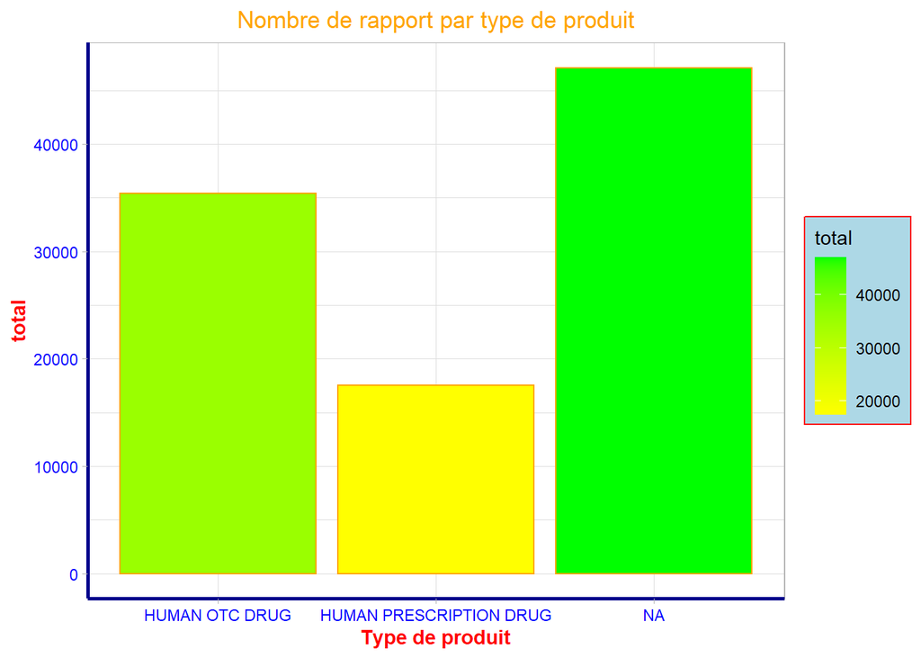

```r
# Graphe
graphe_5 <- req_4 %>% ggplot(aes(product_type, total, fill = total)) +
                      geom_bar(stat = "identity", color = "orange") +
                      theme_light() +
                      xlab("Type de produit") +
                      scale_fill_gradient(low = "yellow", high = "green") +
                      ggtitle("Nombre de rapport par type de produit") +
                      theme(plot.title = element_text(color = "orange", hjust = 0.5),
                            axis.title.x = element_text(color = "red", face = "bold"),
                            axis.title.y = element_text(color = "red", face = "bold"),
                            axis.line = element_line(colour = "darkblue", size = 1, linetype = "solid"),
                            axis.text = element_text(color = "blue"),
                            legend.background = element_rect(fill = "lightblue",
                            size=0.5, linetype="solid", colour = "red"))
graphe_5
```

*Nous pouvons voir que nous avons énormément de données sur “Human OTC Drug” et une très grande quantité de soumissions sont inconnus*

### Les voies les plus fréquentes pour prendre les médicaments

```r
# Requête
req_5 <- spl_openfda %>% group_by(route) %>%
                                     summarise(total = n()) %>%
                                     arrange(desc(total)) %>%
                                     mutate(route = factor(route,levels = route[order(total,decreasing = FALSE)])) %>%
                                     head(21)
```

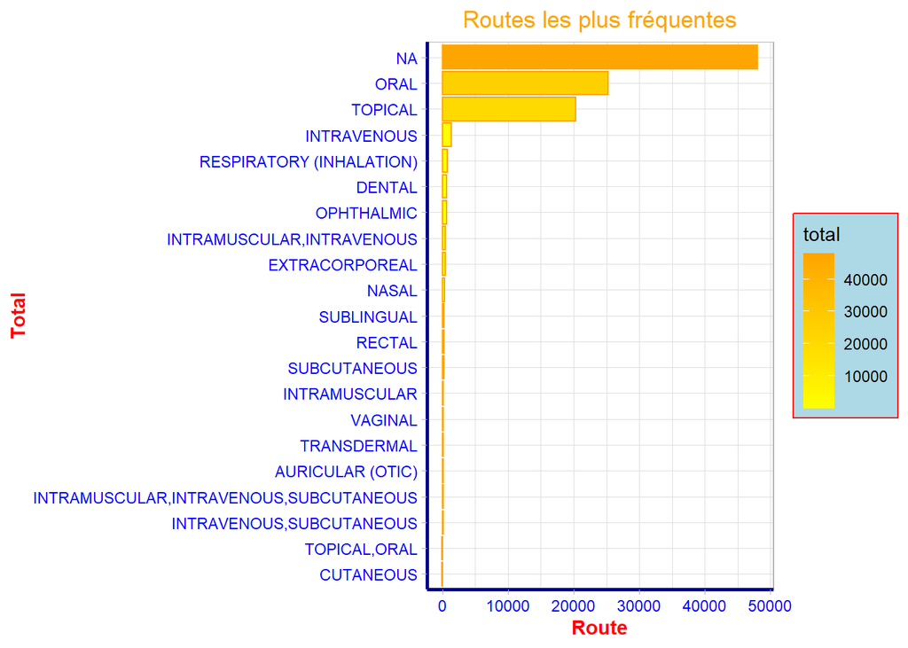

```r
# Graphe
graphe_6 <- req_5 %>% ggplot(aes(route, total, fill = total)) +
                      geom_bar(stat = "identity", color = "orange") +
                      theme_light() +
                      xlab("Total") +
                      ylab("Route") +
                      scale_fill_gradient(low = "yellow", high = "orange") +
                      ggtitle("Routes les plus fréquentes") +
                      theme(plot.title = element_text(color = "orange", hjust = 0.5),
                            axis.title.x = element_text(color = "red", face = "bold"),
                            axis.title.y = element_text(color = "red", face = "bold"),
                            axis.line = element_line(colour = "darkblue", size = 1, linetype = "solid"),
                            axis.text = element_text(color = "blue"),
                            legend.background = element_rect(fill = "lightblue",
                            size=0.5, linetype="solid", colour = "red")) +
                      coord_flip()
graphe_6
```

*La voie la plus utilisé pour prendre les médicaments est la voie Oral puis la voie Topical*

# Concatenons les deux variables “spl” et “spl_openfda”

```r
spl_complet <- cbind(spl,spl_openfda)
head(spl_complet,10)
```

```
##    effective_time boxed_warning                  manufacturer_name
## 1      2020-05-07            NA Tonic Bath & Products Shenzhen Ltd
## 2      2020-05-08            NA                 THE KROGER COMPANY
## 3      2020-05-10            NA                 Earth Edition Inc.
## 4      2018-11-08            NA                                 NA
## 5      2019-11-10            NA                  REMEDYREPACK INC.
## 6      2015-09-25            NA            UniGroup Wholesale Inc.
## 7      2015-08-31            NA                                 NA
## 8      2013-02-19            NA                                 NA
## 9      2018-11-02            NA                                 NA
## 10     2019-12-17            NA                 Crane Safety, LLC.
##               product_type   route
## 1           HUMAN OTC DRUG TOPICAL
## 2           HUMAN OTC DRUG TOPICAL
## 3           HUMAN OTC DRUG TOPICAL
```

[output cut: 29 more lines]

```r
glimpse(spl_complet)
```

```
## Rows: 100,000
## Columns: 8
## $ effective_time    <date> 2020-05-07, 2020-05-08, 2020-05-10, 2018-11-08, ...
## $ boxed_warning     <chr> "NA", "NA", "NA", "NA", "NA", "NA", "NA", "NA", "...
## $ manufacturer_name <chr> "Tonic Bath & Products Shenzhen Ltd", "THE KROGER...
## $ product_type      <chr> "HUMAN OTC DRUG", "HUMAN OTC DRUG", "HUMAN OTC DR...
## $ route             <chr> "TOPICAL", "TOPICAL", "TOPICAL", "NA", "ORAL", "T...
## $ generic_name      <chr> "ETHYL ALCOHOL", "AVOBENZONE, HOMOSALATE, OCTISAL...
## $ brand_name        <chr> "Hand Sanitizer", "KROGER SPORT SPF 15 SUNSCREEN"...
## $ substance_name    <chr> "ALCOHOL", "OCTISALATE,OXYBENZONE,HOMOSALATE,AVOB...
```

### Le nombre de rapports par an par type de produit.

```r
req_6 <- spl_complet %>% mutate(annee = lubridate::year(effective_time)) %>%
                                                  group_by(annee,product_type) %>%
                                                  filter(annee > "2008") %>%
                                                  summarise(total = n())
```

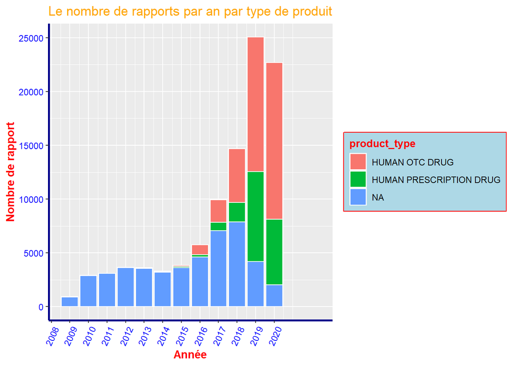

```r
# Graphe
graphe_7 <- req_6 %>% ggplot(aes(annee,total, fill = product_type)) +
                      geom_bar(stat = "identity", color = "white") +
                      ggtitle("Le nombre de rapports par an par type de produit") +
                      xlab("Année") +
                      ylab("Nombre de rapport") +
                      scale_x_continuous(breaks=seq(2008, 2020, by = 1)) +
                      theme(plot.title = element_text(color = "orange", hjust = 0.5),
                            axis.title.x = element_text(color = "red", face = "bold"),
                            axis.title.y = element_text(color = "red", face = "bold"),
                            axis.line = element_line(colour = "darkblue", size = 1, linetype = "solid"),
                            legend.background = element_rect(fill = "lightblue",
                            size=0.5, linetype="solid", colour = "red"),
                            legend.title = element_text(colour = "red", size = 10,face = "bold"),
                            axis.text = element_text(color = "blue"),
                            axis.text.x = element_text(angle = 65, vjust = 0.5))


graphe_7
```

### Quels sont les fabricants ayant le plus grand nombre de rapport chaque année?.

```r
req_7 <- spl_complet %>% mutate(annee = lubridate::year(effective_time)) %>%
                                                  group_by(annee,manufacturer_name) %>%
                                                  filter(annee > "2008", nchar(manufacturer_name) > 2) %>%
                                                  summarise(total = n()) %>%
                                                  top_n(1,wt = total)
```

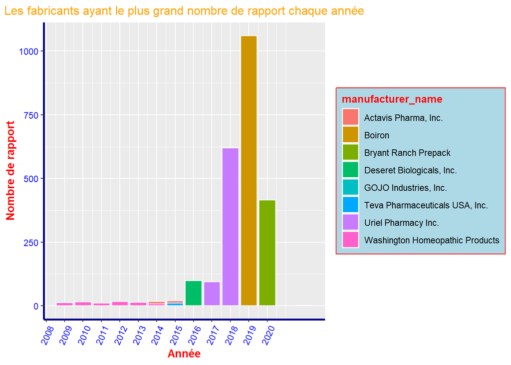

```r
# Graphe
graphe_8 <- req_7 %>% ggplot(aes(annee,total, fill = manufacturer_name)) +
                      geom_bar(stat = "identity", color = "white") +
                      ggtitle("Les fabricants ayant le plus grand nombre de rapport chaque année") +
                      xlab("Année") +
                      ylab("Nombre de rapport") +
                      scale_x_continuous(breaks = seq(2008, 2020, by = 1)) +
                      theme(plot.title = element_text(color = "orange", hjust = 0.5, size = 12),
                            axis.title.x = element_text(color = "red", face = "bold"),
                            axis.title.y = element_text(color = "red", face = "bold"),
                            axis.line = element_line(colour = "darkblue", size = 1, linetype = "solid"),
                            legend.background = element_rect(fill = "lightblue",
                            size=0.5, linetype="solid", colour = "red"),
                            legend.title = element_text(colour = "red", size = 10,face = "bold"),
                            axis.text = element_text(color = "blue"),
                            axis.text.x = element_text(angle = 65, vjust = 0.5))

graphe_8
```

### Quels sont les noms des marques les plus courants chaque année?.

```r
marques_les_plus_courants <- spl_complet %>% mutate(annee = lubridate::year(effective_time)) %>%
                                                  group_by(annee, brand_name) %>%
                                                  filter(annee > "2008",nchar(brand_name) > 2) %>%
                                                  summarise(total = n()) %>%
                                                  arrange(desc(total)) %>%
                                                  top_n(1,wt = total) %>% head(12)
marques_les_plus_courants
```

```
## # A tibble: 12 x 3
## # Groups:   annee [10]
##    annee brand_name                                        total
##    <dbl> <chr>                                             <int>
##  1  2020 Hand Sanitizer                                     2020
##  2  2019 Oxygen                                              248
##  3  2018 Ibuprofen                                            31
##  4  2017 Childrens Loratadine Sugar Free                      10
##  5  2016 Hand Sanitizer                                        7
##  6  2015 anti-bacterial hand gel                               5
##  7  2013 Instant Hand Sanitizer                                3
##  8  2014 Sodium Citrate Blood-Pack Units, (PL 146 Plastic)     3
##  9  2012 Fluocinolone Acetonide                                2
## 10  2012 Hydrogen Peroxide                                     2
## 11  2012 Icy Hot Advanced Relief                               2
## 12  2009 Arnica Nettle                                         1
```

### Conclusion:

*Dans ce post, nous avons télécharger depuis le web, des données au format JSON à partir de l’API OpenFDA sur les produits pharmaceutique, qui procure des données pour l’étiquetage des médicaments sur ordonnace et en vente libre(OTC).* *Nous avons ensuite effectuer quelques analyses sur le contenue de nos données à l’aide de différents packages R pour comprendre les données.* *Lors de mon entretien d’embauche pour intégrer l’entreprise Astrazeneca sis à Cambridge, j’ai eu comme test un “coding style” sur cet API OpenFDA, que j’ai passé avec succès et qui m’a permis de passeraux étapes suivantes et que j’ai effectuer de 2 manières différentes. Ce coding style, je l’ai effectué en python, vous pouvez le retrouver sur la rubrique “python”, avec quelques applications du machine learning qui m’avait été demandé en option dans ce test, pour prédire le nombre d’ingrédients qu’il faudrait dans les années futures, etc…*